# Evaluation Lead case study — Cleaning and analyzing survey data

## Requirements

If you are working in visual studio code, you need to install the following extensions:  
- [Language Server](https://marketplace.visualstudio.com/items?itemName=VisualStudioExptTeam.RLanguageServer) - [R Lang](https://marketplace.visualstudio.com/items?itemName=Ikuyadeu.r)

If you are working in visual studio code and want to use the jupyter notebook version of the codebook, you need to install the following extensions:  
- [R Kernel Notebook](https://marketplace.visualstudio.com/items?itemName=IRkernel.irkernel) - [Jupyter Notebook](https://marketplace.visualstudio.com/items?itemName=mshr-h.VerilogHDL)

## Introduction

The evaluation lead case study is a skills assessment project used to measure candidate’s skill levels in: -  
- quantitative and qualitative data collection and analysis, with an emphasis on quantitative skills, - data analysis using R and other statistical programming languages,  
- data visualization using R and other statistical programming languages,  
- data quality monitoring, data cleaning, coding, analysis, and reporting findings,  
- and communicating results to a non-technical audience.

The project is based on the data for a pre survey and a post survey completed by youth audience members who have viewed a Jack Talk. Jack Talks are mental health presentations delivered by young people to young people. Trained and certified youth speakers use the power of personal stories and mental health education to inspire, engage, educate, and equip young people to look out for themselves and their peers. The pre and post surveys are used to measure the impact of the Jack Talks presentations on the audience.

## Goal

The goal of this project is to clean and analyze the pre and post survey data to determine the impact of the Jack Talks presentations on the audience according to the instructions provided.

## Data

The data for this project is available in the data folder. The data is in the form of two csv files: `pre_survey.csv` and `post_survey.csv`. The data is also available in the package given to candidates. Due to the sensitive nature of the data, the data is not available on GitHub.

## Process

The process for this project is as follows:  
- Read the data into R  
- Clean each individual dataset seperately  
- Combine cleaned datasets into a single dataset  
- Analyze the data  
- Report the findings

The granular steps for each of these processes are given in the instructions provided to candidates. These are also available in the `instructions` folder. The codebook contains all steps and processes taken, it also contains annotations for each step in the process. Codes are written in R, docstrings are included for easy following.

## Deliverables

The deliverables for this project are: - A report in the form of an R Markdown document, (This Markdown document) - A spreadsheet of the cleaned data set in the form of a csv file, (in the `data_output` folder) - A coding script in the form of an R script including annotations for each step in the process, results for requirements 5 and 6, and additional description or notes required to interpret the project. (in the `code` folder)

### Step 1: Data cleaning

The data cleaning process is described in the `data_cleaning codebook` file. The codebook is available in the `code` folder. The process followed for cleaning the data to conform to the seven dimensions of data quality is described below. - Completeness - The data is complete. There are no missing values. - Uniqueness - The data is unique. There are no duplicate values. - Timeliness - The data is timely. The data is current and up to date. - Validity - The data is valid. The data conforms to the data types specified in the instructions. - Accuracy - The data is accurate. The data conforms to the values specified in the instructions. - Consistency - The data is consistent. The data conforms to the values specified in the instructions. - Relevance - The data is relevant. The data meets the standards required for the analysis.

#### 1.1 Asserting test for completeness, uniqueness, timeliness, and relevance.

Quality checks were systematically conducted and data was cleansed in a stepwise manner. As I progressed through the steps, I noticed a reduction in the number of quality violations. This observation suggests that the preceding steps effectively addressed most of the violations. The cleaned datasets were exported to csvs that can be found in the data_output folder. The results are depicted in the table below.

[output not shown]

**Observations**

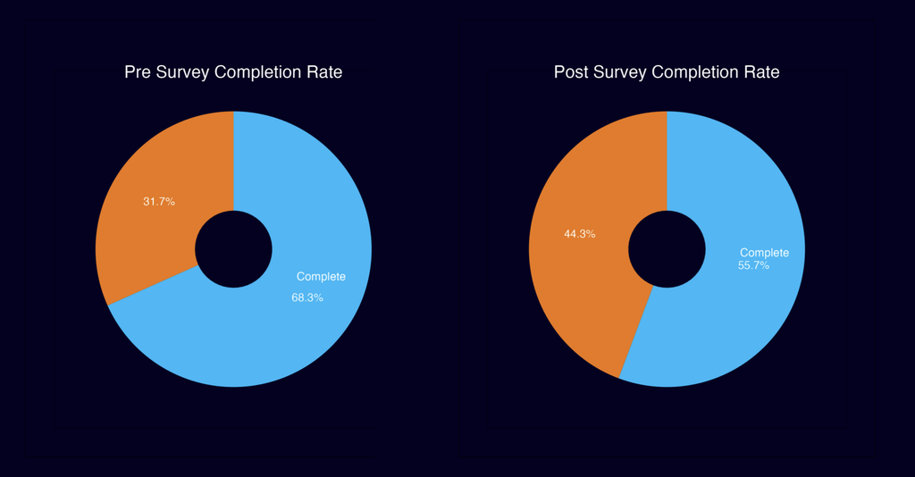

#### 1.2 Merging and exerting tests for validity, accuracy, and consistency.

The two datasets were merged for each same respondent using the `id` columns. The validity, accuracy, and consistency tests were systematically conducted. Data was cleaned using appropiate methods to ensure complaince. The outcome of the tests followed almost a simmilar pattern from the previous step.  
The results are depicted in the table below.

| Quality Dimension | Definition | Result |
| --- | --- | --- |
| Validity | Degree to which the records in a dataset are valid. | The quality assertion here is that post survey cannot be taken before the pre survey. There are at least 262 matching surveys where post-survey was taken before the pre survey by at least 1 day. |
| Accuracy | Degree to which the data is correct and represents the truth. | The assumption is that the data is correct and represents the truth. Further domain knowledge is required to validate accuracy. |
| Consistency | A threshold for how much difference there can be between two datasets. | There was a total of 6,978 records after merging, with only 2,606 matching records. 4,372 records failed this test. |

**Observations**

- A minimum of 262 instances of matching surveys have been observed, in which the post-survey responses were recorded prior to the pre-survey responses by a margin of at least one day. These were removed from the final dataset before analysis of Q6.

```yaml
|   RecordedDate.y(post) |  RecordedDate.x (pre) | Matched |    id      |
|------------------------|-----------------------|---------|------------|
| 2023-03-07 16:20:00    | 2023-05-15 14:05:00   | matched |  A_A_01_A  |
| 2023-05-24 10:26:00    | 2023-05-30 08:53:00   | matched |  A_A_04_B  |
| 2023-03-07 16:21:00    | 2023-05-03 15:22:00   | matched |  A_A_04_M  |
| 2023-04-24 17:01:00    | 2023-05-18 10:39:00   | matched |  A_A_04_P  |
| 2023-05-04 13:13:00    | 2023-05-18 10:37:00   | matched |  A_A_07_8  |
| 2023-05-18 11:19:00    | 2023-05-25 08:58:00   | matched |  A_A_07_R  |
| 2023-02-13 14:58:00    | 2023-05-15 14:05:00   | matched |  A_A_07_S  |
| 2023-05-03 12:55:00    | 2023-05-30 09:28:00   | matched |  A_A_11_H  |
| 2023-04-24 17:02:00    | 2023-05-24 10:55:00   | matched |  A_A_12_A  |
| 2023-05-24 08:39:00    | 2023-05-26 10:17:00   | matched |  A_A_12_F  |

There are 262 row(s) where the post survey date is before the pre-survey date with a difference of more than 1 day.
```

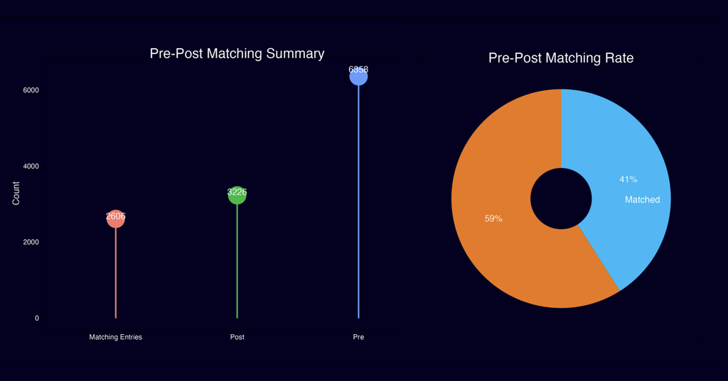

[output not shown]

[figure not shown]

```r
library(ggplot2)

ggplot(mpg, aes(displ, hwy)) +
  geom_point() + geom_smooth()
```

### lattice

```r
lattice::show.settings()
```

[output not shown]

[figure not shown]

### base

[output not shown]

[figure not shown]

```r
plot(pressure, col = thematic::thematic_get_option("accent"))
```